# R Markdown

angelacalicchio

2/17/2022

```r
library(datasets)
data(iris)
# Load Packages
pkgs <- c("rstatix", "emmeans", "psych", "tidyr", "tidyverse", "psych", "dplyr", "ggplot2", "lm.beta", "car", "Hmisc", "skimr", "janitor")
lapply(pkgs, library, character.only = TRUE)
```

# Intro

## Code Chunks

- Most Common
- Use ` (backquote) not ’ (apostrophe)

```r
summary(iris)
```

```
##   Sepal.Length    Sepal.Width     Petal.Length    Petal.Width
##  Min.   :4.300   Min.   :2.000   Min.   :1.000   Min.   :0.100
##  1st Qu.:5.100   1st Qu.:2.800   1st Qu.:1.600   1st Qu.:0.300
##  Median :5.800   Median :3.000   Median :4.350   Median :1.300
##  Mean   :5.843   Mean   :3.057   Mean   :3.758   Mean   :1.199
##  3rd Qu.:6.400   3rd Qu.:3.300   3rd Qu.:5.100   3rd Qu.:1.800
##  Max.   :7.900   Max.   :4.400   Max.   :6.900   Max.   :2.500
##        Species
##  setosa    :50
##  versicolor:50
##  virginica :50
##
##
##
```

```r
# Sum of 2+2
2+2
```

```
## [1] 4
```

```r
# Average Sepal Length
mean(iris$Sepal.Length)
```

```
## [1] 5.843333
```

- When exporting, you will see both of these outputs, but will only see the last one within rmd.
- You can also click the x on the upper right corner of the output to remove the output.

```r
# Levels of Species
unique(iris$Species)
```

```
## [1] setosa     versicolor virginica
## Levels: setosa versicolor virginica
```

# Basics

## Text

Plain text  
End a line with two spaces to start a new paragraph.  
*italics* and *italics*  
**bold** and **bold**  
superscript<sup>2</sup>  
strikethrough  
link

## Headers (level 2)

```r
Make sure to leave a space between the # and your text
# Header 1
## Header 2
```

### Header 3

#### Header 4

##### Header 5

###### Header 6

## Symbols

endash: –  
emdash: —  
ellipsis: …  
inline equation: $A = \pi*r^(2)$

horizontal rule (or slide break):

## Formatting

> block quote
- unordered list
- item 2
  - sub-item 1 (one tab)
  - sub-item 2 (two tabs)

| First Header | Second Header |
| --- | --- |
| Table Cell 1 | Cell 2 |
| Cell 3 | Cell 4 |

## Date

```r
# Add this to date so that today's date is printed whenever doc is knitted
title: "R_Markdown"
auther: "angelacalicchio"
date: "'r Sys.Date()"
```

> Most of this information was taken from this useful [cheatsheet](https://www.rstudio.com/wp-content/uploads/2015/02/rmarkdown-cheatsheet.pdf)

# Code Specifications

## Display Code

```
##   Sepal.Length    Sepal.Width     Petal.Length    Petal.Width
##  Min.   :4.300   Min.   :2.000   Min.   :1.000   Min.   :0.100
##  1st Qu.:5.100   1st Qu.:2.800   1st Qu.:1.600   1st Qu.:0.300
##  Median :5.800   Median :3.000   Median :4.350   Median :1.300
##  Mean   :5.843   Mean   :3.057   Mean   :3.758   Mean   :1.199
##  3rd Qu.:6.400   3rd Qu.:3.300   3rd Qu.:5.100   3rd Qu.:1.800
##  Max.   :7.900   Max.   :4.400   Max.   :6.900   Max.   :2.500
##        Species
##  setosa    :50
##  versicolor:50
##  virginica :50
##
##
##
```

## Display Warnings

```r
warning=TRUE
# Whether to display warnings
```

### With Warnings

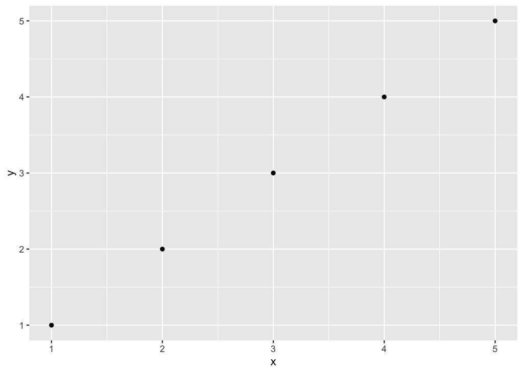

```r
data <- data.frame(x = 1:5,   # Create example data
                   y = 1:5)
ggplot(data, aes(x, y)) +     #Create ggplot2 with default axis limits
  geom_point()
```

```r
ggplot +                         #Modify axis limits
  scale_x_continuous(limits = c(2, 5))
```

[output not shown]

### Without Warnings

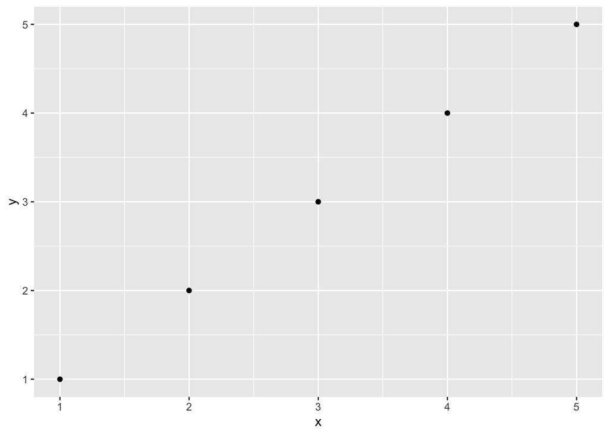

```r
data <- data.frame(x = 1:5,   # Create example data
                   y = 1:5)
ggplot(data, aes(x, y)) +     #Create ggplot2 with default axis limits
  geom_point()
```

```r
ggplot +                         #Modify axis limits
  scale_x_continuous(limits = c(2, 5))
```

[output not shown]

## Display Errors

```r
error=FALSE: Whether to display error message
Default is error=TRUE
```

## Display Output

```r
Default results=FALSE
```

### Output Included

```r
summary(iris)
```

```
##   Sepal.Length    Sepal.Width     Petal.Length    Petal.Width
##  Min.   :4.300   Min.   :2.000   Min.   :1.000   Min.   :0.100
##  1st Qu.:5.100   1st Qu.:2.800   1st Qu.:1.600   1st Qu.:0.300
##  Median :5.800   Median :3.000   Median :4.350   Median :1.300
##  Mean   :5.843   Mean   :3.057   Mean   :3.758   Mean   :1.199
##  3rd Qu.:6.400   3rd Qu.:3.300   3rd Qu.:5.100   3rd Qu.:1.800
##  Max.   :7.900   Max.   :4.400   Max.   :6.900   Max.   :2.500
##        Species
##  setosa    :50
##  versicolor:50
##  virginica :50
##
##
##
```

### Output Not Included

```r
summary(iris)
```

## Display Messages

```r
Default message=TRUE
```

### Messages Not Included

```r
# load packages
pkgs <- c("rstatix", "emmeans", "psych", "tidyr", "tidyverse", "psych", "dplyr", "ggplot2", "lm.beta", "car", "Hmisc", "skimr", "janitor")
lapply(pkgs, library, character.only = TRUE)
```

## Other Specifications

```r
message=TRUE: Whether to display messages
eval=TRUE: Whether to evaluate the code and include its results
tidy=FALSE: Whether to reformat code in a tidy way when displaying it
fig.width=7: Width in inches for plots created in chunk
fig.height=7: Height in inches for plots created in chunk
```

## Bold Code

```r
### <b>
x <- 10
y <- x * 2
### </b>
```

# Table of Contents

## Basic TOC

```r
title: "R Markdown"
author: "angelacalicchio"
date: "'r Sys.Date()'"
output:
  html_document
  toc: true
  toc_depth: 2 #This includes up to two headers
```

## Floatting TOC

```r
title: R Markdown
author: angelacalicchio
date: r Sys.Date()
output:
  html_document
  toc: true
  toc_float: true
  collapsed: true #If TOC appears with only top-level headers
  smooth_scroll: true #Whether page scrolls are animated with mouse clicks
  toc_depth: 3
```

# Tabs

- You can make it so that all subheadings are tabbed by using the {.tabset} command after your heading title.

## Study 1

```r
e.g. = study 1 graph
```

## Study 2

```r
e.g. = study graph 2
```

# Appearances

## Themes

### Built in Themes

- See here for a gallary of the different [themes](https://www.datadreaming.org/post/r-markdown-theme-gallary/)

```r
# Specify this in the beginning of the doc (we are using yeti theme)
theme: Specifies theme to use from the Bootswatch theme library
Specify: default, cerulean, journal, flatly, darkly, readable, spacelab, united, cosmo, lumen, paper, sandstone, simplex, and yeti (use null for no theme)
```

### Downloadable Themes

- Once you download/install this package you can use it when you create a new rmarkdown

```r
# There are a couple downloadable themes, and this is one
# This won't run automatically if you knit this script so you will need to run each line to install and load the package.
install.packages('rmdformats')
library(rmdformats)
```

## Highlight

```r
# Specify this in the beginning of the doc
Highlight: Specifies syntax highlighting style

Specify: default, tango, pygments, kate, monochrome, espresso, zenburn, haddock, breezedark, and textmate (use null for no highlight)
```

## Smart

```r
# Specify this in the beginning of the doc
Smart changes: straight quotes to curly quotes, --- to em-dashes, -- to en-dashes, and ... to ellipses.

Smart is enabled by default
```

### Data Frame Printing

```r
# df_print: specifies how data is printed
# df_print = paged, creates a pageable table

output:
  html_document:
    df_print: paged
```

# Figures

## Embedded Images

```r
image: ![](*enter image id here*){width=50%}
Added {width=50%} to make it half the page, but don't have to use this
```

## Creating Images

```r
# Specify this in the beginning of the doc
fig_width: 7
fig_height: 7
fig_caption: true #Adds captions to figures
dev: png #Specifies type of images figures will be
```

# Advanced Inline Code

```r
# Run anova
model <- aov(Sepal.Length ~ Species, data = iris)
summary(model)
```

```
##              Df Sum Sq Mean Sq F value Pr(>F)
## Species       2  63.21  31.606   119.3 <2e-16 ***
## Residuals   147  38.96   0.265
## ---
## Signif. codes:  0 '***' 0.001 '**' 0.01 '*' 0.05 '.' 0.1 ' ' 1
```

```r
# Create clean tibble from output using broom package
library(broom)
modelmatrix <- broom::tidy(model)

# Round to 3 decimals for clean output
modelmatrix$statistic <- sprintf(modelmatrix$statistic, fmt = '%#.3f')
modelmatrix$p.value <- sprintf(modelmatrix$p.value, fmt = '%#.3f')

modelmatrix
```

| term | df | sumsq | meansq | statistic | p.value |
| --- | --- | --- | --- | --- | --- |
| Species | 2 | 63.21213 | 31.6060667 | 119.265 | 0.000 |
| Residuals | 147 | 38.95620 | 0.2650082 | NA | NA |

> There is a significant main effect of Species on Sepal Length, *F*(2, 147) = 119.265, *p* = 0.000).

# Notes

> 1. Using ~ in your paths doesn’t work with rmd
> 2. Be mindful of the pathways/working directory you are using
> 3. Make sure you are knitting the right type of doc(if it is html, knit it as html)
> 4. Make sure you are using ` (backquote) not ’ (apostrophe)
> 5. Make sure you are capitalizing all letters in the {r} code specifications.
> - You want {r, eval=FALSE}
> - You don’t want {r, eval=False}
> 6. The knitted doc is different depending on which type of rmarkdown script you use (html vs. pdf, etc.)
> 7. Don’t forget to add a space between the # and the header!
> 8. To hide library loadings use both results=FALSE and message=FALSE